# lesson29

Andrew Do

August 1, 2016

## Connecting to a database

To connect to a SQL database, you’ll need to use the appropriate `src_*` function. This tells `R` where to look for data, but unlike our `read_*` functions, the data is not stored into memory.

```r
chinook <- src_sqlite("Chinook_Sqlite.sqlite")
```

Once you’ve connected to a database, you can see what tables are available by calling on the connection:

```r
chinook
```

```
## src:  sqlite 3.8.6 [Chinook_Sqlite.sqlite]
## tbls: Album, Artist, Customer, Employee, Genre, Invoice, InvoiceLine,
##   MediaType, Playlist, PlaylistTrack, Track
```

To actually see a table, you use the `tbl` function. `tbl` is actually used in a second way, which we’ll talk about soon.

```r
chinook %>% tbl("Album")
```

```
## Source:   query [?? x 3]
## Database: sqlite 3.8.6 [Chinook_Sqlite.sqlite]
##
##    AlbumId                                 Title ArtistId
##      <int>                                 <chr>    <int>
## 1        1 For Those About To Rock We Salute You        1
## 2        2                     Balls to the Wall        2
## 3        3                     Restless and Wild        2
## 4        4                     Let There Be Rock        1
## 5        5                              Big Ones        3
## 6        6                    Jagged Little Pill        4
## 7        7                              Facelift        5
## 8        8                        Warner 25 Anos        6
## 9        9        Plays Metallica By Four Cellos        7
## 10      10                            Audioslave        8
## # ... with more rows
```

## Relational databases

Up until this point, when we’ve been using the tidy data model in which we think of our observations as being single rows of our data frame with all variables of interest contained in this single flat table. While this certainly makes plotting and analyzing much easier, it’s not a very scalable model—a naive wrangling sequence can generate temporary tables that are too large for memory.

Enter the relational database model where we store our data in multiple related tables. The `chinook` dataset we’ll be looking at today has the following **schema**, which is just a fancy word meaning “how the data is organized”.

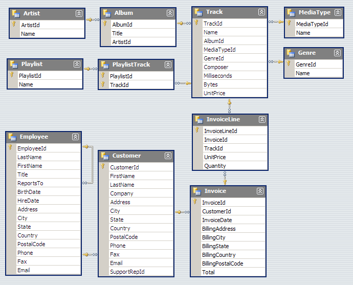

Chinook Data Schema

By far, the most successful and widespread language for data administration, storage, and manipulation is SQL, which stands for Structured Query Language. While there are many implementations of SQL, including MySQL, NoSQL, PostGreSQL, SQLite, etc., their basic functionalities are more or less the same with the main differences being availability of advanced functions. We will mainly focus on SQLite since it’s very quick to use with the `dplyr` package.

Another thing to note is that SQL has three major components. It is a:

- Data Definition Language
  - Allows for creation and modification of relational schema
  - Schema objects include relations, indexes, etc
- Data Manipulation Language
  - Insert, delete, update rows in tables
  - Query data in tables
- Data Control Language
  - Concurrency control, transactions
  - Administrative tasks, e.g. set up database servers, security permissions

Our focus will be on a bullet subpoint: querying existing data in tables. Talking about all the nuances of databases can actually take an entire semester (take CS186 if you’re interested).

## SELECT (well this looks oddly familiar)

Let’s start with `SELECT` as your first function. The basic syntax is `SELECT column_list FROM table_list`

For example, I’ll build our first query from the `Track` table:

```r
my_first_query <- sql("
  SELECT
    trackid,
    name,
    composer,
    unitprice
  FROM
    Track
")
```

And to execute:

```r
chinook %>% tbl(my_first_query)
```

```
## Source:   query [?? x 4]
## Database: sqlite 3.8.6 [Chinook_Sqlite.sqlite]
##
##    trackid                                    name
##      <int>                                   <chr>
## 1        1 For Those About To Rock (We Salute You)
## 2        2                       Balls to the Wall
## 3        3                         Fast As a Shark
## 4        4                       Restless and Wild
## 5        5                    Princess of the Dawn
## 6        6                   Put The Finger On You
## 7        7                         Let's Get It Up
## 8        8                        Inject The Venom
## 9        9                              Snowballed
## 10      10                              Evil Walks
## # ... with more rows, and 2 more variables: composer <chr>,
## #   unitprice <dbl>
```

A few of things to note:

- To construct a SQL call with `dplyr`, you need to provide the query as a string to the `sql` function.
- The whitespace isn’t necessary—I could have equivalently done

```r
sql("SELECT trackid,name,composer,unitprice FROM Track")
```

- To run the query, I use the `tbl` function with the connection as my first argument and the query as my second.

To select all the columns from a table, use the asterisk `*`

```r
my_second_query <- sql("
  SELECT * FROM Track
")
chinook %>% tbl(my_second_query)
```

```
## Source:   query [?? x 9]
## Database: sqlite 3.8.6 [Chinook_Sqlite.sqlite]
##
##    TrackId                                    Name AlbumId MediaTypeId
##      <int>                                   <chr>   <int>       <int>
## 1        1 For Those About To Rock (We Salute You)       1           1
## 2        2                       Balls to the Wall       2           2
## 3        3                         Fast As a Shark       3           2
## 4        4                       Restless and Wild       3           2
## 5        5                    Princess of the Dawn       3           2
## 6        6                   Put The Finger On You       1           1
## 7        7                         Let's Get It Up       1           1
## 8        8                        Inject The Venom       1           1
## 9        9                              Snowballed       1           1
## 10      10                              Evil Walks       1           1
## # ... with more rows, and 5 more variables: GenreId <int>, Composer <chr>,
## #   Milliseconds <int>, Bytes <int>, UnitPrice <dbl>
```

Notice that `dplyr` doesn’t actually load all of the data from the query. This is to save you from accidentally pulling in huge amounts of data and killing your memory. If you want more than the first 10 rows, you use the `collect` function and specify how many rows you want to see. To see the result of the entire query, specify `n = Inf`.

```r
chinook %>% tbl(my_first_query) %>% collect(n = 5)
```

```
## # A tibble: 5 x 4
##   TrackId                                    Name
##     <int>                                   <chr>
## 1       1 For Those About To Rock (We Salute You)
## 2       2                       Balls to the Wall
## 3       3                         Fast As a Shark
## 4       4                       Restless and Wild
## 5       5                    Princess of the Dawn
## # ... with 2 more variables: Composer <chr>, UnitPrice <dbl>
```

```r
chinook %>% tbl(my_first_query) %>% collect(n = Inf)
```

```
## # A tibble: 3,503 x 4
##    TrackId                                    Name
##      <int>                                   <chr>
## 1        1 For Those About To Rock (We Salute You)
## 2        2                       Balls to the Wall
## 3        3                         Fast As a Shark
## 4        4                       Restless and Wild
## 5        5                    Princess of the Dawn
## 6        6                   Put The Finger On You
## 7        7                         Let's Get It Up
## 8        8                        Inject The Venom
## 9        9                              Snowballed
## 10      10                              Evil Walks
## # ... with 3,493 more rows, and 2 more variables: Composer <chr>,
## #   UnitPrice <dbl>
```

The printout looks similar, but notice that the object is now a `tibble` with a specific number of rows rather than a `query` with `??` rows.

## ORDER BY

`ORDER BY` is pretty straightforward. It comes after the `FROM` clause, and you can specify ascending or descending with `ASC` and `DESC`. I’ll just provide some examples:

```r
chinook %>% tbl(sql("
  SELECT
    name,
    milliseconds,
    albumid
  FROM
    Track
  ORDER BY
    albumid ASC
"))
```

```
## Source:   query [?? x 3]
## Database: sqlite 3.8.6 [Chinook_Sqlite.sqlite]
##
##                                       name milliseconds albumid
##                                      <chr>        <int>   <int>
## 1  For Those About To Rock (We Salute You)       343719       1
## 2                    Put The Finger On You       205662       1
## 3                          Let's Get It Up       233926       1
## 4                         Inject The Venom       210834       1
## 5                               Snowballed       203102       1
## 6                               Evil Walks       263497       1
## 7                                   C.O.D.       199836       1
## 8                       Breaking The Rules       263288       1
## 9                 Night Of The Long Knives       205688       1
## 10                              Spellbound       270863       1
## # ... with more rows
```

The `ASC` is actually unnecessary since it’s the default. You can also sort on multiple columns. This works the same way as `arrange` does in `dplyr`

```r
chinook %>% tbl(sql("
  SELECT
    name,
    milliseconds,
    albumid
  FROM
    Track
  ORDER BY
    albumid ASC,
    milliseconds DESC
"))
```

```
## Source:   query [?? x 3]
## Database: sqlite 3.8.6 [Chinook_Sqlite.sqlite]
##
##                                       name milliseconds albumid
##                                      <chr>        <int>   <int>
## 1  For Those About To Rock (We Salute You)       343719       1
## 2                               Spellbound       270863       1
## 3                               Evil Walks       263497       1
## 4                       Breaking The Rules       263288       1
## 5                          Let's Get It Up       233926       1
## 6                         Inject The Venom       210834       1
## 7                 Night Of The Long Knives       205688       1
## 8                    Put The Finger On You       205662       1
## 9                               Snowballed       203102       1
## 10                                  C.O.D.       199836       1
## # ... with more rows
```

You can also specify the ordering by column position. The index refers to the position specified in the `SELECT` clause. Here 3 refers to `albumid` and 2 refers to `milliseconds`.

```r
chinook %>% tbl(sql("
  SELECT
    name,
    milliseconds,
    albumid
  FROM
    Track
  ORDER BY
    3,2
"))
```

```
## Source:   query [?? x 3]
## Database: sqlite 3.8.6 [Chinook_Sqlite.sqlite]
##
##                                       name milliseconds albumid
##                                      <chr>        <int>   <int>
## 1                                   C.O.D.       199836       1
## 2                               Snowballed       203102       1
## 3                    Put The Finger On You       205662       1
## 4                 Night Of The Long Knives       205688       1
## 5                         Inject The Venom       210834       1
## 6                          Let's Get It Up       233926       1
## 7                       Breaking The Rules       263288       1
## 8                               Evil Walks       263497       1
## 9                               Spellbound       270863       1
## 10 For Those About To Rock (We Salute You)       343719       1
## # ... with more rows
```

## SELECT DISTINCT (huh, more similarities)

You’ll often run into the case where selecting only a subset of the attributes leads to duplicates in your data

```r
chinook %>% tbl(sql("
  SELECT
    city
  FROM
    Customer
  ORDER BY
    city
")) %>% collect
```

```
## # A tibble: 59 x 1
##            City
##           <chr>
## 1     Amsterdam
## 2     Bangalore
## 3        Berlin
## 4        Berlin
## 5      Bordeaux
## 6        Boston
## 7     BrasÃlia
## 8      Brussels
## 9      Budapest
## 10 Buenos Aires
## # ... with 49 more rows
```

Notice that Berlin appears twice. What if we want a list of distinct cities for our customers? In comes `SELECT DISTINCT`, which removes duplicate ROWS.

```r
chinook %>% tbl(sql("
  SELECT DISTINCT
    city
  FROM
    Customer
")) %>% collect
```

```
## # A tibble: 53 x 1
##                     City
##                    <chr>
## 1  SÃ£o JosÃ© dos Campos
## 2              Stuttgart
## 3              MontrÃ©al
## 4                   Oslo
## 5                 Prague
## 6                 Vienne
## 7               Brussels
## 8             Copenhagen
## 9             SÃ£o Paulo
## 10        Rio de Janeiro
## # ... with 43 more rows
```

## WHERE (aka filter)

`WHERE` fills in the role of `filter()` from `dplyr`. It has the following syntax:

```
SELECT
  column_list
FROM
  table
WHERE
  search_condition
```

### Comparison Operators

`WHERE` understands the following comparison operators

| Operator | Meaning |
| --- | --- |
| = | Equal to |
| <> or != | Not equal to |
| < | Less than |
| > | Greater than |
| <= | Less than or equal to |
| >= | Greater than or equal to |

### Logical Operators

SQLite understand the following logical operators

| Operator | Meaning |
| --- | --- |
| ALL | returns 1 if all expressions are 1. |
| AND | returns 1 if both expressions are 1, and 0 if one of the expressions is 0. |
| ANY | returns 1 if any one of a set of comparisons is 1. |
| BETWEEN | returns 1 if a value is within a range. |
| EXISTS | returns 1 if a subquery contains any rows. |
| IN | returns 1 if a value is in a list of values. |
| LIKE | returns 1 if a value matches a pattern |
| NOT | reverses the value of other operators such as NOT EXISTS, NOT IN, NOT BETWEEN, etc. |
| OR | returns true if either expression is 1 |

### Examples

```r
chinook %>% tbl(sql("
  SELECT
    name,
    milliseconds,
    bytes,
    albumid
  FROM
    Track
  WHERE
    albumid = 1
")) %>% collect
```

```
## # A tibble: 10 x 4
##                                       Name Milliseconds    Bytes AlbumId
##                                      <chr>        <int>    <int>   <int>
## 1  For Those About To Rock (We Salute You)       343719 11170334       1
## 2                    Put The Finger On You       205662  6713451       1
## 3                          Let's Get It Up       233926  7636561       1
## 4                         Inject The Venom       210834  6852860       1
## 5                               Snowballed       203102  6599424       1
## 6                               Evil Walks       263497  8611245       1
## 7                                   C.O.D.       199836  6566314       1
## 8                       Breaking The Rules       263288  8596840       1
## 9                 Night Of The Long Knives       205688  6706347       1
## 10                              Spellbound       270863  8817038       1
```

Here is an example of a compound expression

```r
chinook %>% tbl(sql("
  SELECT
    name,
    milliseconds,
    bytes,
    albumid
  FROM
    Track
  WHERE
    albumid = 1
    AND milliseconds > 250000
")) %>% collect
```

```
## # A tibble: 4 x 4
##                                      Name Milliseconds    Bytes AlbumId
##                                     <chr>        <int>    <int>   <int>
## 1 For Those About To Rock (We Salute You)       343719 11170334       1
## 2                              Evil Walks       263497  8611245       1
## 3                      Breaking The Rules       263288  8596840       1
## 4                              Spellbound       270863  8817038       1
```

`IN` functions like well… `%in%` from base `R`.

```r
chinook %>% tbl(sql("
  SELECT
    name,
    albumid,
    mediatypeid
  FROM
    Track
  WHERE
    mediatypeid IN (2, 3)
")) %>% collect
```

```
## # A tibble: 451 x 3
##                     Name AlbumId MediaTypeId
##                    <chr>   <int>       <int>
## 1      Balls to the Wall       2           2
## 2        Fast As a Shark       3           2
## 3      Restless and Wild       3           2
## 4   Princess of the Dawn       3           2
## 5  Welcome to the Jungle      90           2
## 6           It's So Easy      90           2
## 7              Nightrain      90           2
## 8          Out Ta Get Me      90           2
## 9         Mr. Brownstone      90           2
## 10         Paradise City      90           2
## # ... with 441 more rows
```

To negate a statement, use `NOT`

```r
chinook %>% tbl(sql("
  SELECT
    trackid,
    name,
    genreid
  FROM
    Track
  WHERE
    genreid NOT IN (1, 2, 3)
")) %>% collect
```

```
## # A tibble: 1,702 x 3
##    TrackId                  Name GenreId
##      <int>                 <chr>   <int>
## 1       99    Your Time Has Come       4
## 2      100          Out Of Exile       4
## 3      101           Be Yourself       4
## 4      102     Doesn't Remind Me       4
## 5      103       Drown Me Slowly       4
## 6      104         Heaven's Dead       4
## 7      105              The Worm       4
## 8      106         Man Or Animal       4
## 9      107 Yesterday To Tomorrow       4
## 10     108             Dandelion       4
## # ... with 1,692 more rows
```

`LIKE` allows you to perform an inexact search. The `%` acts like `.*` in regular expressions. Say for example, you want to find all `composer` with `Smith` in their name.

```r
chinook %>% tbl(sql("
  SELECT
    name,
    albumid,
    composer
  FROM
    Track
  WHERE
    composer LIKE '%Smith%'
  ORDER BY
    albumid
")) %>% collect
```

```
## # A tibble: 97 x 3
##                       Name AlbumId
##                      <chr>   <int>
## 1        Restless and Wild       3
## 2     Princess of the Dawn       3
## 3            Killing Floor      19
## 4              Machine Men      19
## 5    2 Minutes To Midnight      95
## 6  Can I Play With Madness      96
## 7     The Evil That Men Do      96
## 8           The Wicker Man      97
## 9         The Fallen Angel      97
## 10          Wildest Dreams      98
## # ... with 87 more rows, and 1 more variables: Composer <chr>
```

`_` functions like `.` in regular expressions. The following would be like searching for `".*Br.wn.*"`:

```r
chinook %>% tbl(sql("
  SELECT
    trackid,
    name
  FROM
    Track
  WHERE
    name LIKE '%Br_wn%'
")) %>% collect
```

```
## # A tibble: 2 x 2
##   TrackId                 Name
##     <int>                <chr>
## 1    1053 Bad, Bad Leroy Brown
## 2    1150       Mr. Brownstone
```